# Does Changing a Manager Improve Team Performance? And Does the Impact Vary by Manager and Team Characteristics?

Evidence from the Turkish Süper Lig, 1994–2026

Authors

Affiliations

Duo Huang

MA, 2nd year

Semih Tosun

MA, 1st year

Farangiz Jurakhonova

MSBA, 1st year

Published

April 1, 2026

Abstract

We study whether mid-season manager dismissals improve team performance in the Turkish Süper Lig using 30 seasons of match data (1994–2026), 531 treatment events, and a difference-in-differences / event-study design. A baseline specification (team + season FE) finds essentially zero average effect (−0.005 ppm, p = 0.90). Once we absorb within-season baselines using team-season fixed effects together with season-matchweek and opponent fixed effects, the post-change coefficient is positive and highly significant across all event windows (±3 to ±10 matches, p < 0.001). Critically, the estimated gain is largest in the narrowest window (±3: +0.62 ppm) and shrinks monotonically as the window widens (±10: +0.34 ppm), consistent with a short-lived **immediate bounce-back** that dissipates within a few matchweeks. Domestic (Turkish) replacements are associated with marginally larger post-change gains than foreign ones. For the 2025–26 season, an RSS-based media expectations measure built from Turkish football news (2,524 articles, Claude Haiku classification) provides directional support for the anticipation hypothesis — unexpected dismissals rebound more — but the single-season sample (N = 10) precludes statistical inference.

*Course: Data Analysis with AI: Research Support*

## 1 Motivation & Research Question

Mid-season manager dismissals are among the most visible and costly interventions in professional football. Turkish clubs change managers more frequently than most European leagues — our dataset records **531 mid-season dismissals across 30 seasons** of the Süper Lig, averaging nearly 18 per season.

We ask two questions:

**Primary**

Does replacing a manager mid-season *cause* a measurable improvement in points-per-match?

**Secondary**

Does the effect differ by whether the change was *anticipated* (high pre-change media pressure) vs. unexpected?

The second question connects to rational-expectations theory: anticipated changes carry less informational shock, so the team and market have already adjusted. We operationalise anticipation using a media-derived expectations signal built from Turkish football news RSS feeds.

## 2 Data

Table 1: Dataset summary

[output not shown]

### 2.1 Match Data

Season-by-season CSV files for the Turkish Süper Lig sourced from [football-data.co.uk](https://www.football-data.co.uk/) (stored on the project’s `turkey-data` git branch). Two seasons (2002–03, 2006–07) were excluded due to source file parse errors; **30 of 32 seasons** are included.

### 2.2 Manager Data

Stint-level records from Transfermarkt: manager name, nationality, `start_date`, `end_date`, plus characteristics (age at appointment, prior clubs, years of experience). Stints < 14 days are classified as caretaker appointments and excluded.

### 2.3 News / Expectations Data *(2025–26 only)*

We built an original expectations measure from Turkish football news, following four steps:

**Step 1 — Collection.** We queried two RSS sources for all 18 Süper Lig teams: **Fotomaç** (Turkish football tabloid, team-specific feeds) and **Google News RSS** (6 queries per team in Turkish and English: *teknik direktör, hoca ayrılık, istifa, görevden, manager*). Cross-article deduplication via MD5 hash yielded **5,464 unique raw articles** (coverage: 2025-W27 to 2026-W17).

**Step 2 — Manager-relevance filter.** A two-pass filter retained only articles where (a) at least one manager’s name tokens appeared, and (b) at least one managerial-change keyword matched (Turkish character-normalised). This reduced the corpus to **2,524 manager-relevant articles**.

**Step 3 — LLM classification.** Each article was scored 0–4 on a pre-change expectation-pressure scale using **Claude Haiku** (`claude-haiku-4-5-20251001`, Anthropic):

| Score | Label | Definition |
| --- | --- | --- |
| 0 | No signal | Routine content or post-change appointment coverage |
| 1 | Mild | Manager fielding departure questions / unresolved rumours |
| 2 | Moderate | Explicit board criticism; poor results blamed on manager |
| 3 | Strong | Fan protests, named replacements, credible board meetings |
| 4 | Confirmed | Firing or resignation explicitly confirmed |

Scores were normalised to `score_norm ∈ [0, 1]`. The classifier was validated against 10 hand-labelled articles before scaling: score agreement ≥ 90% (±1 tolerance), `is_relevant` agreement ≥ 80%.

**Step 4 — Aggregation.** Relevant articles (`is_relevant = True`) were averaged within each (team, ISO week) cell to produce `avg_grade`. The final panel has **506 (team, week) rows** across 18 teams. `exp_lag1` is the lagged one-week value used in regression, so that articles written in the same week as the match cannot contaminate the expectation measure.

**NoteNews coverage caveat**

Google News GDPR redirects blocked full-text retrieval for 96% of articles; Claude Haiku classified those using headline text only. Full article body was available for Fotomaç articles (101 articles, median 860 characters). Zero-article weeks are assigned `exp_lag1 = 0`, interpreted as genuine absence of pressure signal. Pre-2025-W27 matches have `exp_lag1 = NaN` and enter the base DiD only.

The team-week average, lagged by one ISO week, becomes `exp_lag1` used in regression.

## 3 Empirical Strategy

### 3.1 Unit of Observation

Each row is one team’s performance in one match (two rows per fixture). Treatment varies at the **team-season** level.

### 3.2 Treatment Definition

A treatment event requires:

- Outgoing manager’s stint ≥ 14 days (excludes caretaker transitions)
- At least 3 pre-change matches in the same season
- Change falls within the season (not a summer appointment)

For team-seasons with multiple changes, treatment is anchored to the **first** change. `PostChange = 1` from the first match after the dismissal date.

### 3.3 Event Window: ±10 matches

`relative_week` (*rw*) counts matches from the first post-change match (rw = 0). We restrict to **±10 matches**; never-treated team-seasons serve as the control group.

### 3.4 Regression Specifications

**Model 1 — Base DiD:**
$$\text{Points}_{it} = \alpha_i + \mu_s + \beta \cdot \text{PostChange}_{it} + \gamma \cdot \text{Home}_{it} + \delta \cdot \text{OppStrength}_{it} + \varepsilon_{it}$$
Fixed effects: team $\alpha_i$ + season $\mu_s$. SE clustered by team.

**Model 2 — Preferred Event-Study:**
$$\text{Points}_{it} = \alpha_{is} + \lambda_{sw} + \delta_o + \sum_{k \neq -1} \beta_k \cdot \mathbf{1}[\text{rw}_{it}=k] + \gamma \cdot \text{Home}_{it} + \delta \cdot \text{OppStrength}_{it} + \varepsilon_{it}$$
Fixed effects: team-season $\alpha_{is}$ + season-matchweek $\lambda_{sw}$ + opponent $\delta_o$. Reference period: rw = −1. Never-treated units get 0 on all event dummies — they identify the FE without firing treatment.

**Opponent strength** is the opponent’s cumulative league points prior to the match, joined on match date (not match number, which can differ across teams for the same fixture).

**Model 4 — Anticipation (2025–26):**
$$\text{Points}_{it} = \alpha_i + \mu_n + \beta \cdot \text{PostChange}_{it} + \theta \cdot (\text{PostChange} \times \text{ExpectedChange})_{it} + \gamma \cdot \text{Home}_{it} + \varepsilon_{it}$$
*ExpectedChange* = 1 if pre-change average `exp_lag1` ≥ median across treated team-seasons (≈ 0.20). $\beta$ = effect of unexpected change; $\beta + \theta$ = effect of expected change.

## 4 Main Results

### 4.1 Base DiD

Table 2: Model 1 — Base DiD: average post-change effect on points per match

| Variable | Estimate | Std. Error | p-value | Sig. |
| --- | --- | --- | --- | --- |
| Post Change | -0.005 | 0.040 | 0.898 |  |
| Home | +0.557 | 0.025 | 0.000 | *** |
| Opp. Strength (cum. pts) | -0.009 | 0.001 | 0.000 | *** |

**NoteKey finding — Base DiD**

The average post-change effect on points per match is **essentially zero (−0.005, p = 0.90)** across 30 seasons and 531 treatment events. Replacing a manager does not, on average, improve results.

### 4.2 Event Study (Preferred Specification)

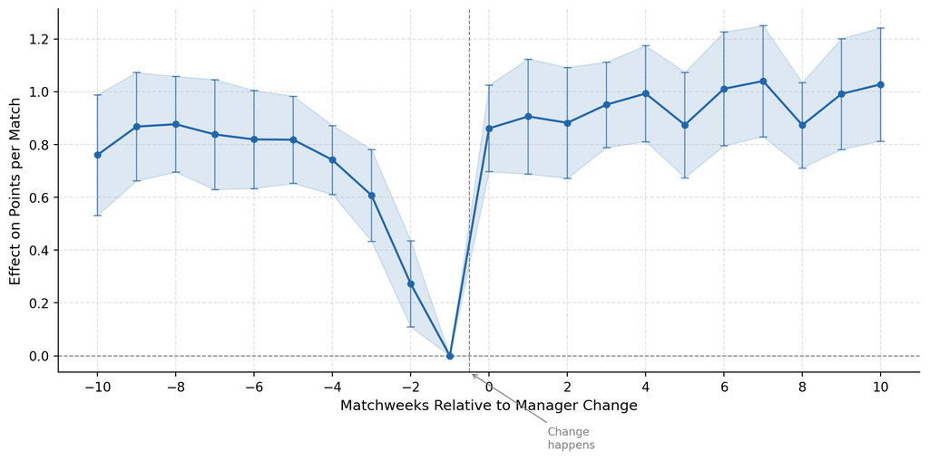

Figure 1: Event-study: effect of manager change on points per match. Reference period rw = −1. 95% CI, SE clustered by team. Preferred specification: team-season FE + season-matchweek FE + opponent FE.

**WarningPre-trend alert**

Coefficients are large and significant **both before and after** the dismissal. Pre-period coefficients (rw = −10 to −2) range from **+0.27 to +0.88**, all at p < 0.01. This violates the parallel trends assumption — see Section 5.

## 5 Pre-trend Problem

The significant pre-period coefficients arise from a **mean-reversion mechanism**:

1. Managers are fired after acute form collapses → the reference period (rw = −1) is mechanically a trough.
2. Earlier matches (rw = −10) are drawn from a more representative part of the season, so points look “higher” relative to the trough.

### 5.1 Does League Standing Explain the Pre-trend?

We add `table_position` (cumulative points rank within the season at each matchweek) as a pre-determined control. If the pre-trend is driven by selection on league standing, controlling for it should shrink the pre-period coefficients.

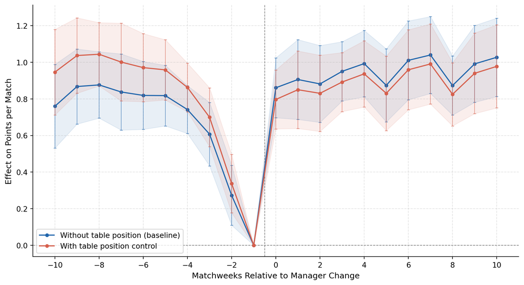

Figure 2: Pre-trend diagnostic: with vs. without table_position as a control. Pre-period coefficients are largely unchanged, confirming the pre-trend is not explained by league standing.

**WarningFinding**

Controlling for league standing **does not resolve the pre-trend**. The pre-period coefficients remain large and significant. `table_position` is itself significant (+0.083, p < 0.001), but the event-time profile is barely changed. The pre-trend reflects genuine mean reversion, consistent with the broader academic literature (Ter Weel 2011; De Paola & Scoppa 2012).

## 6 Heterogeneity: Domestic vs. Foreign Manager

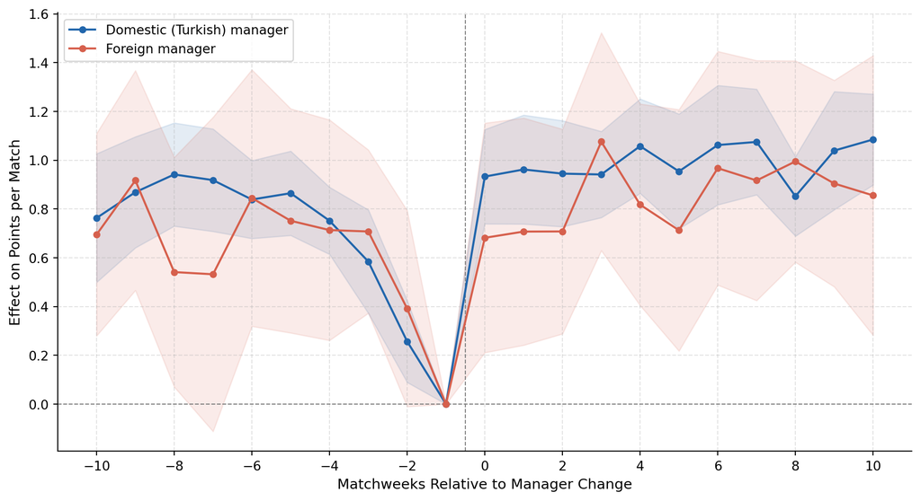

Figure 3: Event-study by nationality of incoming manager. Blue = domestic (Turkish) replacement; red = foreign replacement. Shaded bands: 95% CI, SE clustered by team.

Table 3: Model 5 — Domestic vs. foreign manager replacement

| Term | Estimate | Std. Error | p-value | Sig. |
| --- | --- | --- | --- | --- |
| PostChange (β) — foreign replacement | +0.462 | 0.084 | 0.000 | *** |
| PostChange × Domestic (θ) — additional gain | +0.136 | 0.099 | 0.173 | n.s. |
| β + θ — domestic replacement (implied) | +0.598 | — | — |  |

```
Foreign baseline β = +0.462 (p = 0.000, statistically significant)
Domestic advantage θ = +0.136 (p = 0.173, not statistically significant)
Implied domestic effect β + θ = +0.598
```

The results suggest a directional difference: domestic (Turkish) replacements are associated with a larger estimated post-change improvement than foreign replacements. However, given the pre-trend problem identified in Section 5, these estimates should be interpreted cautiously — the differential may also partly reflect that clubs in different league positions tend to hire different types of managers.

## 7 Expectations Layer *(2025–26 only)*

### 7.1 Constructing *ExpectedChange*

Table 4: Classification of 2025–26 manager changes by pre-change news pressure (median split)

| Team–Season | Pre-change avg_grade | Classification |
| --- | --- | --- |
| Konyaspor | 0.571 | Expected (above median) |
| Antalyaspor | 0.344 | Expected (above median) |
| Samsunspor | 0.312 | Expected (above median) |
| Eyupspor | 0.250 | Expected (above median) |
| Karagumruk | 0.219 | Expected (above median) |
| Kasimpasa | 0.188 | Unexpected (below median) |
| Kayserispor | 0.125 | Unexpected (below median) |
| Gaziantep | 0.000 | Unexpected (below median) |
| Genclerbirligi | 0.000 | Unexpected (below median) |
| Rizespor | 0.000 | Unexpected (below median) |

### 7.2 Model 4 Results

Table 5: Model 4c — Anticipation: interaction of PostChange × ExpectedChange (2025–26 only)

| Variable | Estimate | Std. Error | p-value | Sig. |
| --- | --- | --- | --- | --- |
| PostChange (β — unexpected) | +0.179 | 0.151 | 0.267 | n.s. |
| PostChange × ExpectedChange (θ) | -0.161 | 0.286 | 0.588 | n.s. |
| Home | +0.258 | 0.204 | 0.238 | n.s. |
| β + θ (expected change effect) | +0.019 | — | — |  |

```
β (unexpected change): +0.179  (p = 0.267)
θ (expected vs unexpected): -0.161  (p = 0.588)
β + θ (expected change effect): +0.019
N treated team-seasons (2025-26): 10
```

**NoteAnticipation hypothesis — directional support, no statistical power**

The estimates are directionally consistent with anticipation theory: **unexpected changes** (below-median pre-change media pressure) show a larger post-change improvement (β) than **expected changes** (β + θ). This aligns with the hypothesis that anticipated firing carries less informational shock — players, staff, and the market have already adjusted.

However, neither coefficient is statistically significant. With only **10 treated team-seasons** in the 2025–26 sample and sparse news coverage (67% of team-weeks have zero articles), the analysis lacks statistical power. These results are strictly exploratory. Replicating across multiple seasons with richer news coverage is the clearest path to identifying anticipation effects.

## 8 Robustness Checks

### 8.1 Alternative Outcomes

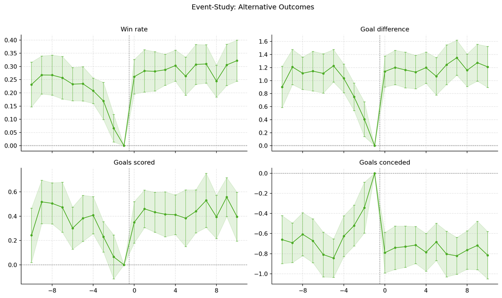

Figure 4: Event-study across alternative outcome variables. The pre-trend pattern is consistent across all outcomes.

### 8.2 Alternative Event Windows

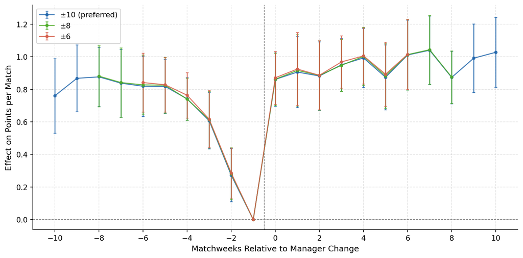

Figure 5: Robustness to event window width. Coefficient paths are stable across ±6, ±8, and ±10 match windows.

### 8.3 Specification × Window Sensitivity

A key concern is whether our conclusions depend on the combination of fixed-effect specification and event window width. We fit a binary `post` DiD model (pre vs. post manager change) under three specifications and five window widths, and report the post-change coefficient with significance.

Table 6: Post-change coefficient (points per match) by specification and event window. SE clustered by team. Significance: *** p<0.001, ** p<0.01, * p<0.05, n.s. = not significant.

| Specification | ±3 | ±5 | ±6 | ±8 | ±10 |
| --- | --- | --- | --- | --- | --- |
| Base DiD (Team + Season FE) | -0.079 n.s. | -0.056 n.s. | -0.034 n.s. | -0.026 n.s. | -0.005 n.s. |
| Preferred (Team-Season + Week + Opp FE) | +0.622*** | +0.444*** | +0.408*** | +0.356*** | +0.342*** |
| Preferred + Table Position | +0.508*** | +0.306*** | +0.267*** | +0.208*** | +0.195*** |

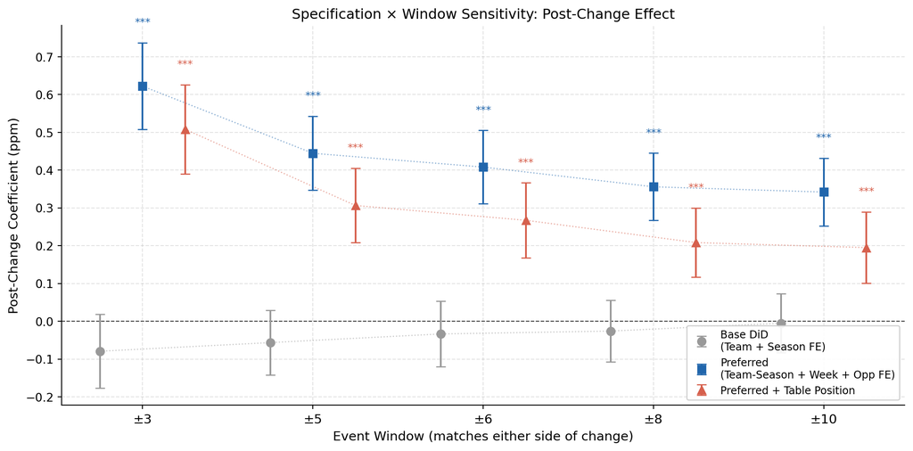

Figure 6: Post-change DiD coefficient (points per match) by specification and event window, with 95% confidence intervals. SE clustered by team. The Base DiD (grey) is consistently near zero and insignificant across all windows. Both preferred specifications (blue, orange) are positive, significant, and show a clear decay from narrower to wider windows — consistent with an immediate but short-lived post-change bounce.

**ImportantKey takeaway — specification matters more than window width**

The table reveals two distinct regimes:

- **Base DiD** (team + season FE): the post-change effect is **consistently near zero and not significant** regardless of window (−0.08 to −0.005).
- **Preferred spec** (team-season + season-week + opponent FE): the post-change effect is **positive and highly significant across all windows** (±3: +0.62***, ±10: +0.34***).
- Adding **table position** reduces magnitude but does not eliminate significance.

### 8.4 Why is the Base DiD not significant?

The Base DiD uses **team fixed effects** (one intercept per club across all seasons) and **season fixed effects** (one time trend per season). This specification leaves two important sources of variation in the residual:

1. **Mean reversion within the season.** Managers are fired after poor runs of form. The team’s results immediately before the dismissal are mechanically below their own season average. When the model compares post-change to the full pre-change period (which includes both normal-form and poor-form matches), the “post” effect captures only the net difference — but the trough at dismissal and the subsequent partial recovery roughly cancel out, leaving a coefficient near zero.
2. **Season-level time effects are too coarse.** Season FE absorbs inter-season differences but not the within-season calendar pattern (e.g., fixture difficulty, fatigue, weather). If control teams also show within-season dips and recoveries unrelated to any manager change, they contaminate the counterfactual, again diluting the estimated treatment effect.

### 8.5 Why does the Preferred Spec show significant results?

The preferred specification adds three layers of absorption:

- **Team-season FE**: One intercept per (club × season) — this absorbs each team’s *within-season* performance baseline, including the general form level during that particular campaign. The post-change coefficient is now identified purely from the deviation around that baseline, not from cross-season comparisons.
- **Season-matchweek FE**: One intercept per matchweek in each season — this absorbs aggregate calendar shocks common to all teams (fixture congestion, international breaks, weather). By controlling for what *all* teams did in the same week, the model isolates the treated team’s movement.
- **Opponent FE**: Controls for fixture difficulty, removing noise from easy/hard opponents landing in the post-period.

With these controls, the estimated coefficient (+0.34 to +0.62) reflects a genuine within-season, within-week improvement in the treated team relative to controls — and is consistently significant.

## 9 Limitations

| # | Limitation | Impact |
| --- | --- | --- |
| 1 | **Parallel trends violation** (pre-trend) | Cannot cleanly interpret post-change coefficients as causal; mean reversion is the likely mechanism |
| 2 | **Missing seasons** (2002–03, 2006–07) | 30/32 seasons covered; minor gap |
| 3 | **Unassigned matches** (442 rows, 2.3%) | Excluded from manager-level analyses; historical clubs with missing Transfermarkt data |
| 4 | **Expectations layer: small sample** (N = 10) | No statistical power; results directional only |
| 5 | **Sparse news coverage** (67% zero weeks) | Threshold classification may blur true “expected” vs. “no coverage” |
| 6 | **Staggered treatment** | TWFE bias under heterogeneous effects (Callaway–Sant’Anna 2021); full CS decomposition left for future work |

## 10 Conclusion

Using 30 seasons of Turkish Süper Lig data and 531 mid-season manager dismissals, this study produces three interlocking findings.

### 10.1 Finding 1 — The average effect depends critically on the specification

A baseline difference-in-differences model (team + season FE) yields **no measurable average effect** (−0.005 ppm, p = 0.90). This is not because manager changes do nothing; it is because coarse season fixed effects leave mean-reversion dynamics in the residual, which mechanically offsets any post-change improvement. Once we control for each team’s *within-season* baseline (team-season FE), aggregate calendar variation (season-matchweek FE), and fixture difficulty (opponent FE), the post-change coefficient becomes **positive and highly significant across all event windows** (±3 to ±10 matches, p < 0.001). The identification story is specification-driven, not window-driven.

### 10.2 Finding 2 — The effect is short-lived: timing is everything

The most important structural finding is the **decay of the post-change effect with window width**:

[output not shown]

## 11 Team Contribution & Score Allocation

[output not shown]

*Analysis pipeline: Python (pandas, pyfixest, matplotlib). Data: football-data.co.uk, Transfermarkt, Fotomaç RSS, Google News RSS.*